# Homework_4

Sai Jaligama

4/27/2020

1. a

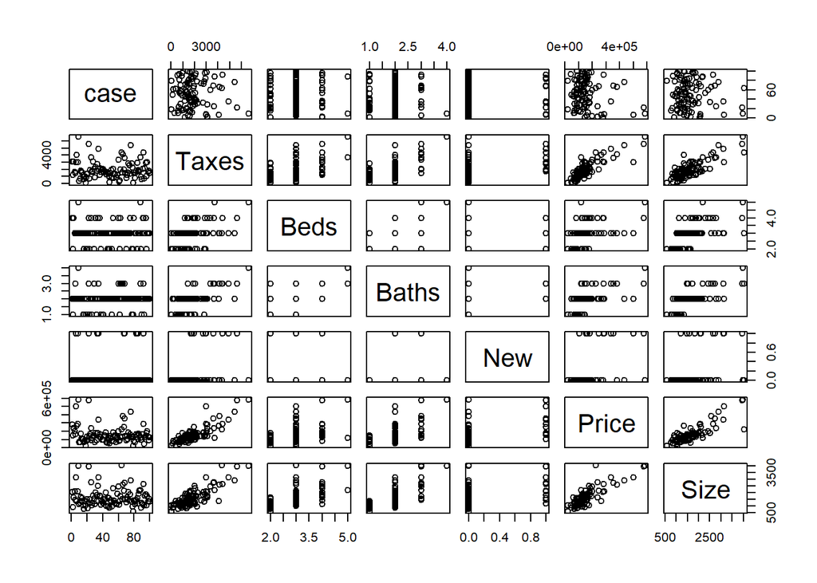

```r
df <- read.table('C:/Users/saija/OneDrive/Desktop/Regression Anlysis/Assign_4/HP.txt',header=TRUE)
pairs(df)
```

```r
head(df)
```

```
##   case Taxes Beds Baths New  Price Size
## 1    1  3104    4     2   0 279900 2048
## 2    2  1173    2     1   0 146500  912
## 3    3  3076    4     2   0 237700 1654
## 4    4  1608    3     2   0 200000 2068
## 5    5  1454    3     3   0 159900 1477
## 6    6  2997    3     2   1 499900 3153
```

```r
model <- lm(Price ~ Size + New + Baths + Beds + Taxes + case,df)
summary(model)
```

```
##
## Call:
## lm(formula = Price ~ Size + New + Baths + Beds + Taxes + case,
##     data = df)
##
## Residuals:
##     Min      1Q  Median      3Q     Max
## -169285  -25338      90   23486  145634
##
## Coefficients:
##               Estimate Std. Error t value Pr(>|t|)
## (Intercept)  25438.941  24726.554   1.029  0.30624
## Size            63.830     13.535   4.716 8.44e-06 ***
## New          44548.626  16317.314   2.730  0.00757 **
## Baths         1725.980  11139.847   0.155  0.87721
## Beds        -10894.828   8791.806  -1.239  0.21839
## Taxes           38.364      6.573   5.836 7.73e-08 ***
## case          -453.821    159.855  -2.839  0.00556 **
## ---
## Signif. codes:  0 '***' 0.001 '**' 0.01 '*' 0.05 '.' 0.1 ' ' 1
##
## Residual standard error: 45560 on 93 degrees of freedom
## Multiple R-squared:  0.8099, Adjusted R-squared:  0.7976
## F-statistic: 66.02 on 6 and 93 DF,  p-value: < 2.2e-16
```

3. Checking for linearity

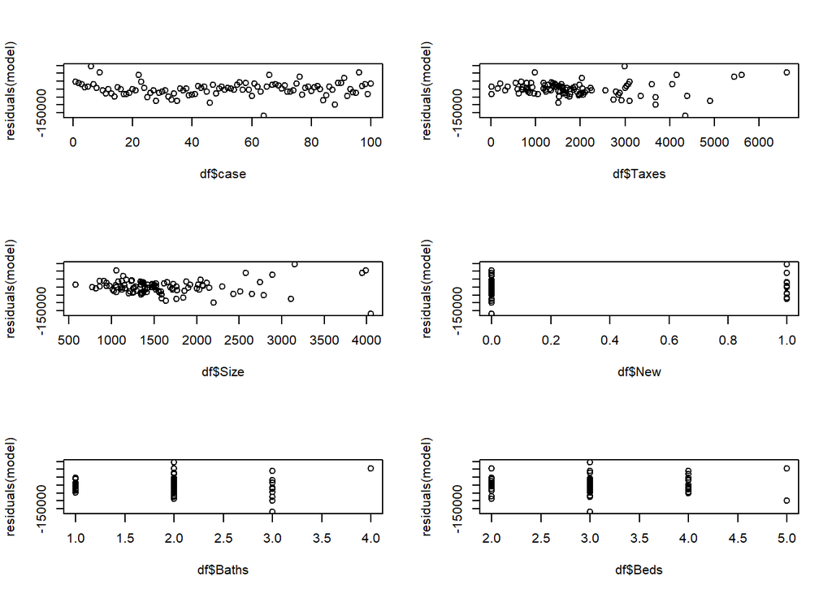

```r
par( mfrow = c(3,2) )
plot(df$case,residuals(model))
plot(df$Taxes,residuals(model))
plot(df$Size,residuals(model))
plot(df$New,residuals(model))
plot(df$Baths,residuals(model))
plot(df$Beds,residuals(model))
```

**Case, Taxes and Size have plots which are random which implies linearity.** **We shall check plots of studentized residuals vs covariates.**

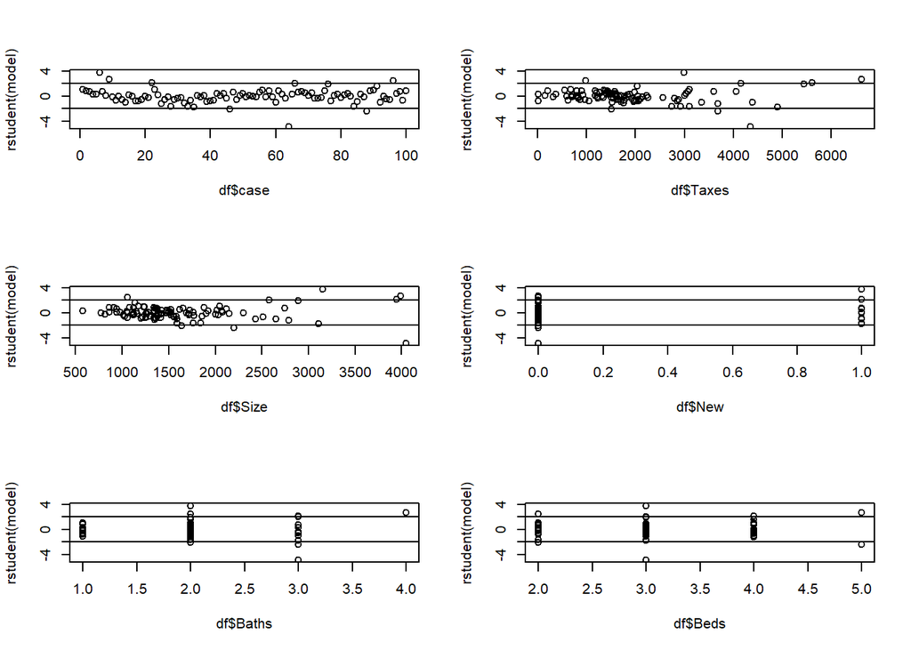

```r
par( mfrow = c(3,2) )
plot(df$case,rstudent(model))
abline(2,0)
abline(-2,0)
plot(df$Taxes,rstudent(model))
abline(2,0)
abline(-2,0)
plot(df$Size,rstudent(model))
abline(2,0)
abline(-2,0)
plot(df$New,rstudent(model))
abline(2,0)
abline(-2,0)
plot(df$Baths,rstudent(model))
abline(2,0)
abline(-2,0)
plot(df$Beds,rstudent(model))
abline(2,0)
abline(-2,0)
```

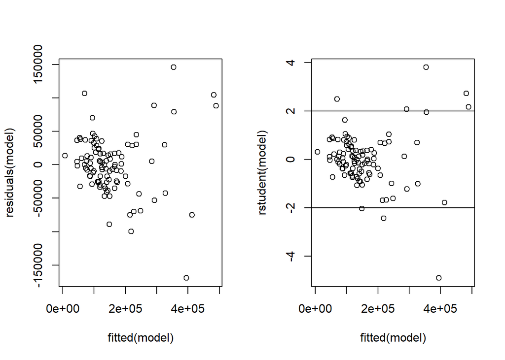

```r
par(mfrow= c(1,2))
plot(fitted(model),residuals(model))
plot(fitted(model),rstudent(model))
abline(2,0)
abline(-2,0)
```

**From the above plot we can see that variance is not constant throughout. As covariates are increasing, the variance in Y is increasing**

**Normaility Assumption check. We plot the Quantile Quantile plot to check normality.**

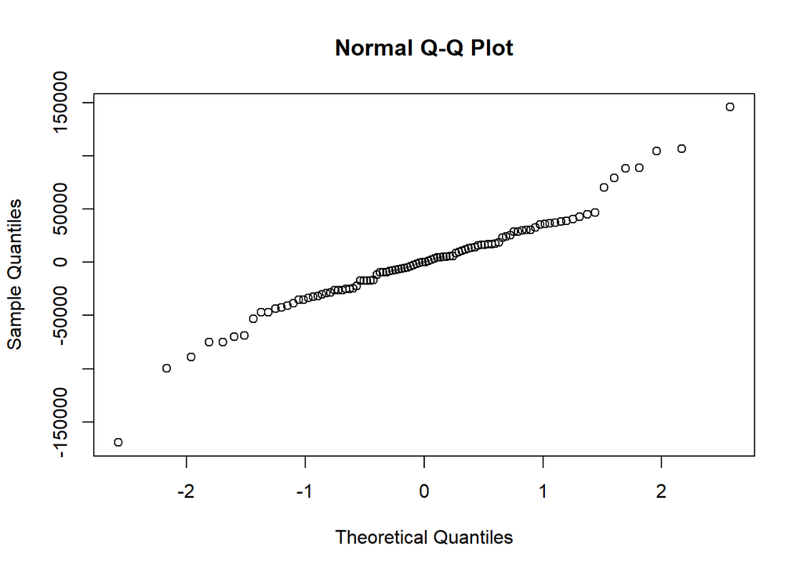

```r
qqnorm(residuals(model))
```

**Ideally we would like the dots to be evenly spaced or closely evenly spaaced. But we can see that this is a heavy tailed, which may indicate that it is not normal.**

**We do not need to check Independence Assumption as we do not have any time variable. For example, We are not checking how the price of a house is affected with time. What was the price in 2010 and what is the price now. If that was the case we would have had to check the independence assumption. For this particular example we assume that the assumption in met.**

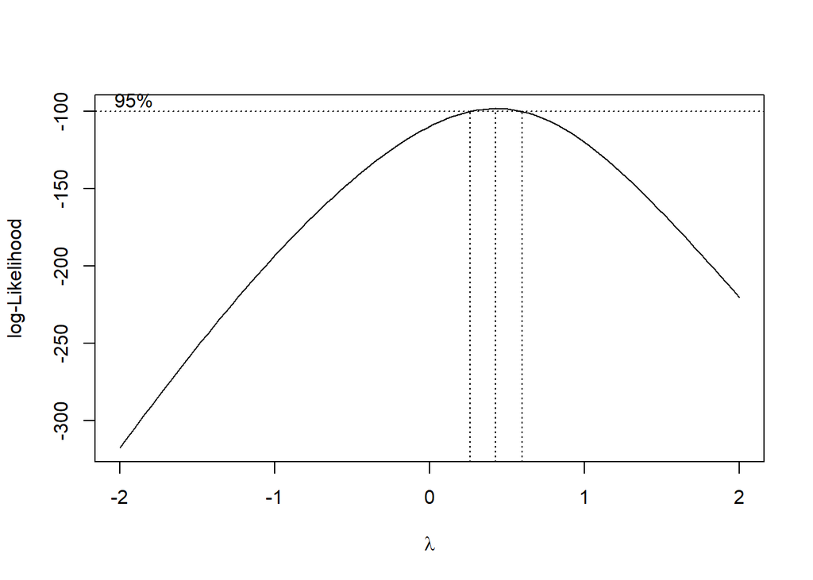

```
## [1] "x" "y"
```

```r
library(MASS)
boxcox(Price ~ Size + New + Baths + Beds + Taxes + case,data = df)
names(boxcox(Price ~ Size + New + Baths + Beds + Taxes + case,data = df))
```

```r
rev(order(boxcox(Price ~ Size + New + Baths + Beds + Taxes + case,data = df)$y))[1]
```

```
## [1] 61
```

```r
boxcox(Price ~ Size + New + Baths + Beds + Taxes + case,data = df)$x[61]
```

```
## [1] 0.4242424
```

**We can see that lambda is 0.5. We shall test this for our model. we shall set y as sqrt(y). And check the assumptions once again.**

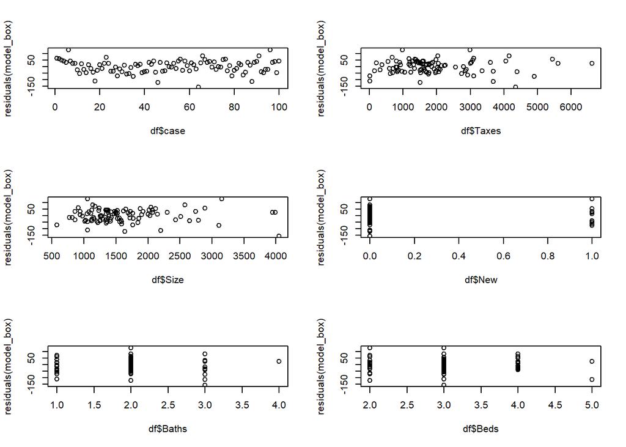

```r
df$Price_new <-df$Price^0.5
model_box <- lm(Price_new ~ Size + New + Baths + Beds + Taxes + case,df)
par( mfrow = c(3,2) )
plot(df$case,residuals(model_box))
plot(df$Taxes,residuals(model_box))
plot(df$Size,residuals(model_box))
plot(df$New,residuals(model_box))
plot(df$Baths,residuals(model_box))
plot(df$Beds,residuals(model_box))
```

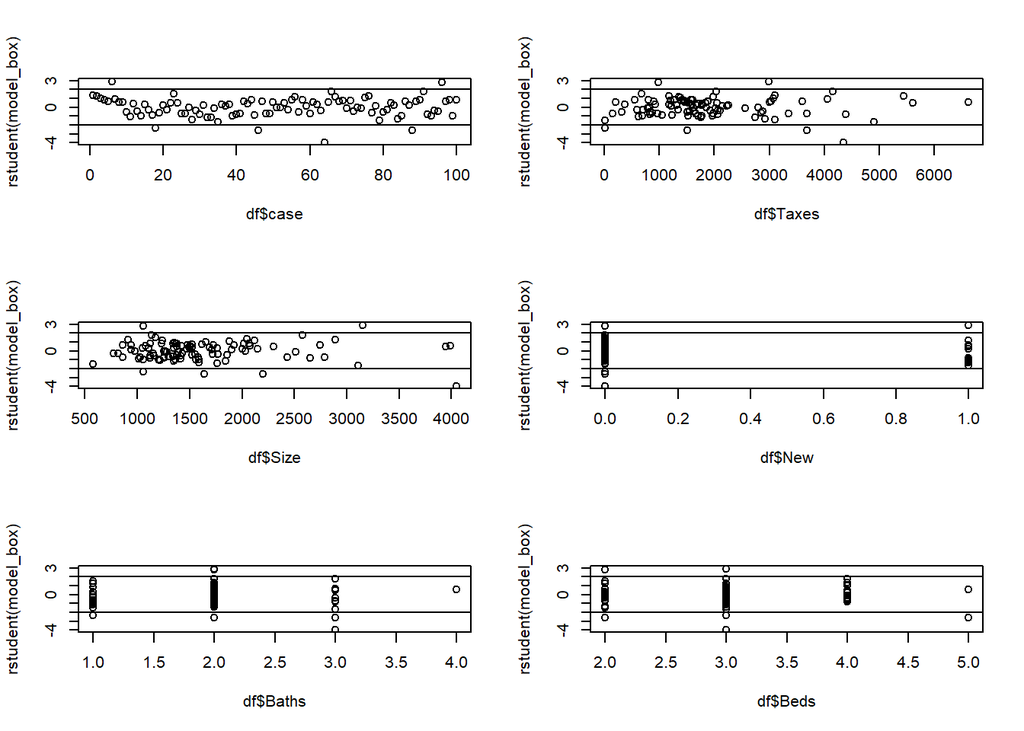

```r
par( mfrow = c(3,2) )
plot(df$case,rstudent(model_box))
abline(2,0)
abline(-2,0)
plot(df$Taxes,rstudent(model_box))
abline(2,0)
abline(-2,0)
plot(df$Size,rstudent(model_box))
abline(2,0)
abline(-2,0)
plot(df$New,rstudent(model_box))
abline(2,0)
abline(-2,0)
plot(df$Baths,rstudent(model_box))
abline(2,0)
abline(-2,0)
plot(df$Beds,rstudent(model_box))
abline(2,0)
abline(-2,0)
```

```r
summary(model)
```

```
##
## Call:
## lm(formula = Price ~ Size + New + Baths + Beds + Taxes + case,
##     data = df)
##
## Residuals:
##     Min      1Q  Median      3Q     Max
## -169285  -25338      90   23486  145634
##
## Coefficients:
##               Estimate Std. Error t value Pr(>|t|)
## (Intercept)  25438.941  24726.554   1.029  0.30624
## Size            63.830     13.535   4.716 8.44e-06 ***
## New          44548.626  16317.314   2.730  0.00757 **
## Baths         1725.980  11139.847   0.155  0.87721
## Beds        -10894.828   8791.806  -1.239  0.21839
## Taxes           38.364      6.573   5.836 7.73e-08 ***
## case          -453.821    159.855  -2.839  0.00556 **
## ---
## Signif. codes:  0 '***' 0.001 '**' 0.01 '*' 0.05 '.' 0.1 ' ' 1
##
## Residual standard error: 45560 on 93 degrees of freedom
## Multiple R-squared:  0.8099, Adjusted R-squared:  0.7976
## F-statistic: 66.02 on 6 and 93 DF,  p-value: < 2.2e-16
```

```r
summary(model_box)
```

```
##
## Call:
## lm(formula = Price_new ~ Size + New + Baths + Beds + Taxes +
##     case, data = df)
##
## Residuals:
##      Min       1Q   Median       3Q      Max
## -158.268  -34.218    6.318   32.585  130.561
##
## Coefficients:
##               Estimate Std. Error t value Pr(>|t|)
## (Intercept) 226.082898  27.414347   8.247 1.03e-12 ***
## Size          0.060836   0.015006   4.054 0.000104 ***
## New          45.472208  18.091018   2.514 0.013673 *
## Baths         6.227070  12.350757   0.504 0.615324
## Beds        -10.074061   9.747482  -1.034 0.304048
## Taxes         0.045426   0.007288   6.233 1.32e-08 ***
## case         -0.405045   0.177232  -2.285 0.024562 *
## ---
## Signif. codes:  0 '***' 0.001 '**' 0.01 '*' 0.05 '.' 0.1 ' ' 1
##
## Residual standard error: 50.51 on 93 degrees of freedom
## Multiple R-squared:  0.8043, Adjusted R-squared:  0.7917
## F-statistic: 63.72 on 6 and 93 DF,  p-value: < 2.2e-16
```

**We can see there is not much change int the R squared and adjusted R squared score.**

5. Influential observations/Outliers

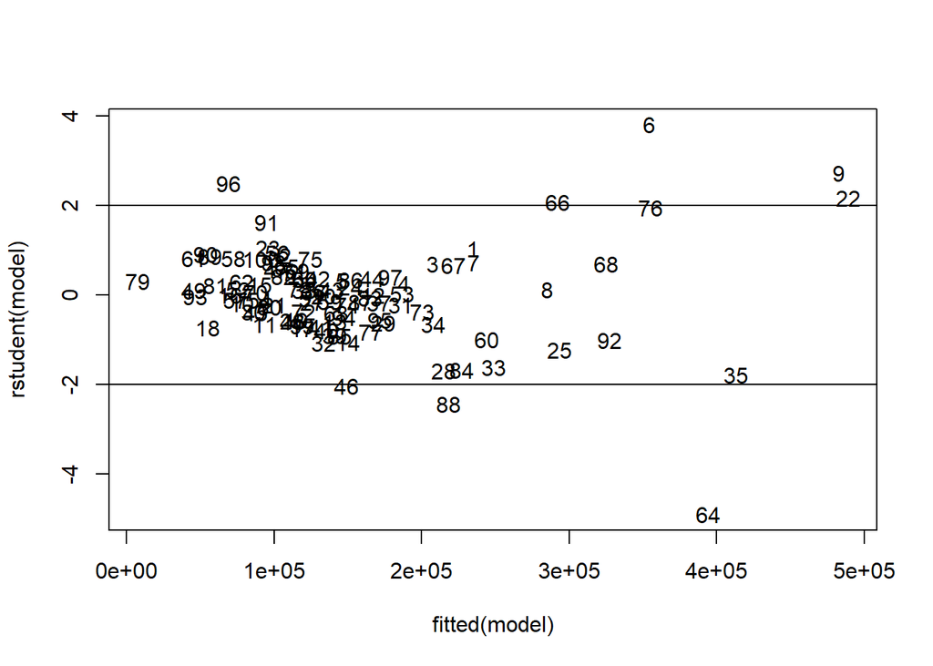

```r
plot(fitted(model),rstudent(model),type="n")
text(fitted(model),rstudent(model))
abline(2,0)
abline(-2,0)
```

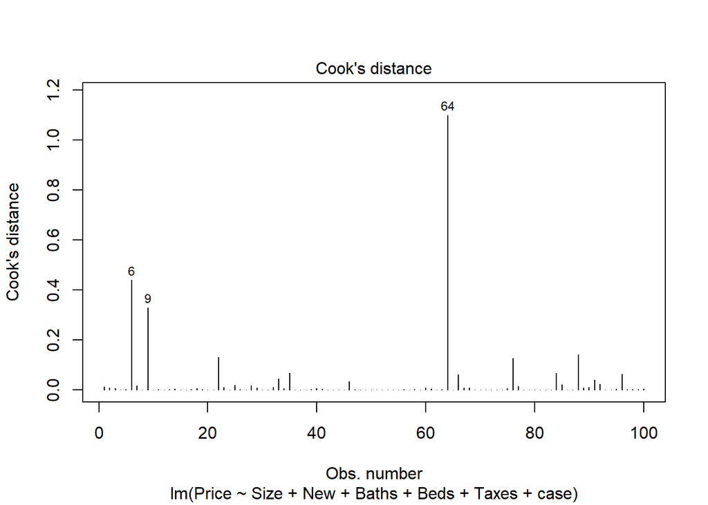

```r
plot(model,which=4)
```

**Record number 64 is influential because Di is more than 1.**

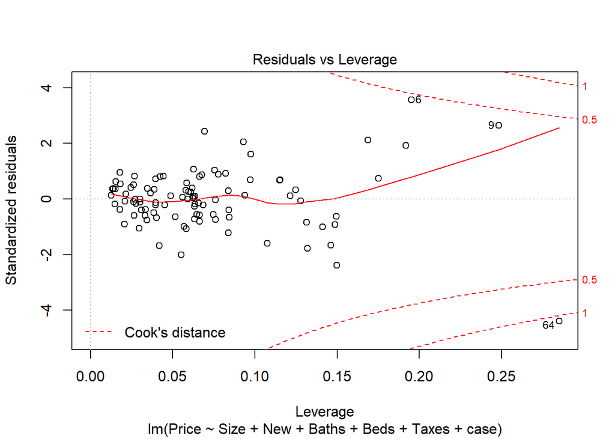

```r
plot(model,which=5)
```

**Rcord number 64 is an influential observation. Let us check what it is.**

```r
df[64,]
```

```
##    case Taxes Beds Baths New  Price Size Price_new
## 64   64  4350    3     3   0 225000 4050  474.3416
```

**This is our influential observation.**

2. a

```r
df <- read.table('C:/Users/saija/OneDrive/Desktop/Regression Anlysis/Assign_4/AAPL.txt',header=TRUE)
head(df)
```

```
##       Date Week ClosePrice
## 1 11-10-24    1     404.95
## 2 11-10-31    2     400.24
## 3 11-11-07    3     384.62
## 4 11-11-14    4     374.94
## 5 11-11-21    5     363.57
## 6 11-11-28    6     389.70
```

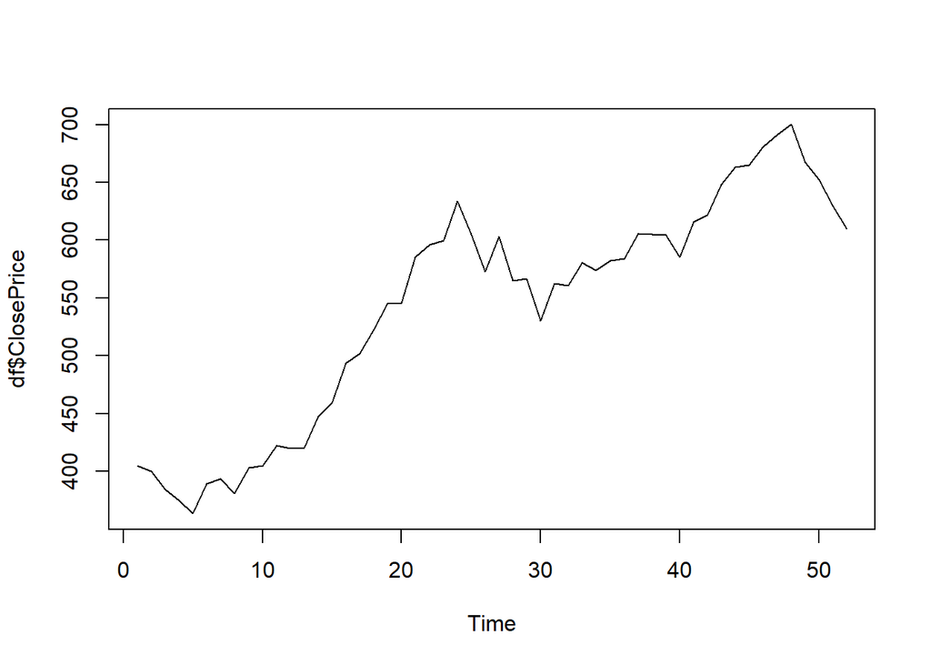

```r
ts.plot(df$ClosePrice)
```

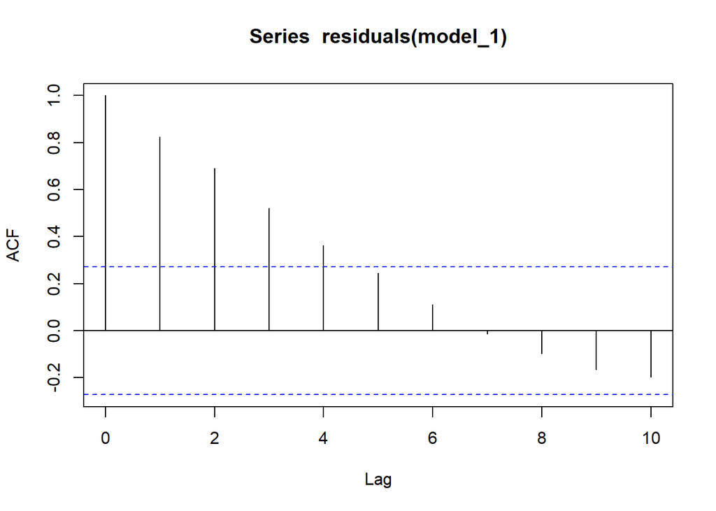

```r
model_1 = lm(ClosePrice~Week,df)
acf(residuals(model_1),lag.max = 10)
```

**No. this is not a good model as we can see the lines are crossing the dotted line which is +-2/sqrt(n). A good model would be the one where the lines would not cross the blue dotted line.**